# Risk Factor Analysis

## Outcome Variable

**Outcome Variable:** ever_stunted

## Predictor Variables

**Intervention Variable:** feducyrs

**Adjustment Set:**

unadjusted

## Stratifying Variables

The analysis was stratified on these variable(s):

- agecat
- studyid

The following strata were considered:

- agecat: 12 months, studyid: ki0047075b-MAL-ED
- agecat: 12 months, studyid: ki1000304b-SAS-FoodSuppl
- agecat: 12 months, studyid: ki1017093b-PROVIDE
- agecat: 12 months, studyid: ki1017093c-NIH-Crypto
- agecat: 12 months, studyid: ki1066203-TanzaniaChild2
- agecat: 12 months, studyid: ki1113344-GMS-Nepal
- agecat: 12 months, studyid: ki1126311-ZVITAMBO
- agecat: 12 months, studyid: ki1135781-COHORTS
- agecat: 12 months, studyid: ki1148112-LCNI-5
- agecat: 18 months, studyid: ki0047075b-MAL-ED
- agecat: 18 months, studyid: ki1000304b-SAS-FoodSuppl
- agecat: 18 months, studyid: ki1017093b-PROVIDE
- agecat: 18 months, studyid: ki1017093c-NIH-Crypto
- agecat: 18 months, studyid: ki1066203-TanzaniaChild2
- agecat: 18 months, studyid: ki1113344-GMS-Nepal
- agecat: 18 months, studyid: ki1126311-ZVITAMBO
- agecat: 18 months, studyid: ki1135781-COHORTS
- agecat: 18 months, studyid: ki1148112-LCNI-5
- agecat: 24 months, studyid: ki0047075b-MAL-ED
- agecat: 24 months, studyid: ki1000304b-SAS-FoodSuppl
- agecat: 24 months, studyid: ki1017093b-PROVIDE
- agecat: 24 months, studyid: ki1017093c-NIH-Crypto
- agecat: 24 months, studyid: ki1066203-TanzaniaChild2
- agecat: 24 months, studyid: ki1113344-GMS-Nepal
- agecat: 24 months, studyid: ki1126311-ZVITAMBO
- agecat: 24 months, studyid: ki1135781-COHORTS
- agecat: 24 months, studyid: ki1148112-LCNI-5
- agecat: 3 months, studyid: ki0047075b-MAL-ED
- agecat: 3 months, studyid: ki1017093b-PROVIDE
- agecat: 3 months, studyid: ki1017093c-NIH-Crypto
- agecat: 3 months, studyid: ki1066203-TanzaniaChild2
- agecat: 3 months, studyid: ki1113344-GMS-Nepal
- agecat: 3 months, studyid: ki1126311-ZVITAMBO
- agecat: 3 months, studyid: ki1135781-COHORTS
- agecat: 6 months, studyid: ki0047075b-MAL-ED
- agecat: 6 months, studyid: ki1000304b-SAS-FoodSuppl
- agecat: 6 months, studyid: ki1017093b-PROVIDE
- agecat: 6 months, studyid: ki1017093c-NIH-Crypto
- agecat: 6 months, studyid: ki1066203-TanzaniaChild2
- agecat: 6 months, studyid: ki1113344-GMS-Nepal
- agecat: 6 months, studyid: ki1126311-ZVITAMBO
- agecat: 6 months, studyid: ki1135781-COHORTS
- agecat: 6 months, studyid: ki1148112-LCNI-5

### Dropped Strata

Some strata were dropped due to rare outcomes:

- agecat: 3 months, studyid: ki1017093b-PROVIDE
- agecat: 3 months, studyid: ki1066203-TanzaniaChild2
- agecat: 3 months, studyid: ki1126311-ZVITAMBO
- agecat: 6 months, studyid: ki1017093b-PROVIDE
- agecat: 6 months, studyid: ki1066203-TanzaniaChild2
- agecat: 6 months, studyid: ki1126311-ZVITAMBO
- agecat: 6 months, studyid: ki1148112-LCNI-5
- agecat: 12 months, studyid: ki1000304b-SAS-FoodSuppl
- agecat: 12 months, studyid: ki1017093b-PROVIDE
- agecat: 12 months, studyid: ki1066203-TanzaniaChild2
- agecat: 18 months, studyid: ki1000304b-SAS-FoodSuppl
- agecat: 18 months, studyid: ki1017093b-PROVIDE
- agecat: 18 months, studyid: ki1066203-TanzaniaChild2
- agecat: 18 months, studyid: ki1126311-ZVITAMBO
- agecat: 24 months, studyid: ki1000304b-SAS-FoodSuppl
- agecat: 24 months, studyid: ki1017093b-PROVIDE
- agecat: 24 months, studyid: ki1066203-TanzaniaChild2
- agecat: 24 months, studyid: ki1126311-ZVITAMBO

## Methods Detail

We’re interested in the causal parameters $E[Y_a]$ for all values of $a \in \mathcal{A}$. These parameters represent the mean outcome if, possibly contrary to fact, we intervened to set all units to have $A=a$. Under the randomization and positivity assumptions, these are identified by the statistical parameters $\psi_a=E_W[E_{Y|A,W}(Y|A=a,W)]$. In addition, we’re interested in the mean of $Y$, $E[Y]$ under no intervention (the observed mean). We will estimate these parameters by using SuperLearner to fit the relevant likelihood factors – $E_{Y|A,W}(Y|A=a,W)$ and $p(A=a|W)$, and then updating our likelihood fit using a joint TMLE.

For unadjusted analyses ($W=\{\}$), initial likelihoods were estimated using Lrnr_glm to estimate the simple $E(Y|A)$ and Lrnr_mean to estimate $p(A)$. For adjusted analyses, a small library containing Lrnr_glmnet, Lrnr_xgboost, and Lrnr_mean was used.

Having estimated these parameters, we will then use the delta method to estimate relative risks and attributable risks relative to a prespecified baseline level of $A$.

# Results Detail

## Results Plots

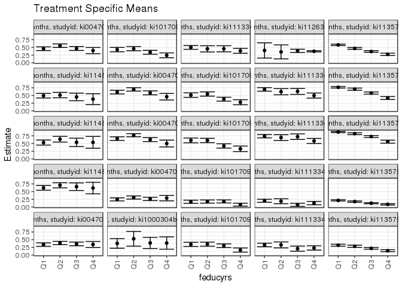

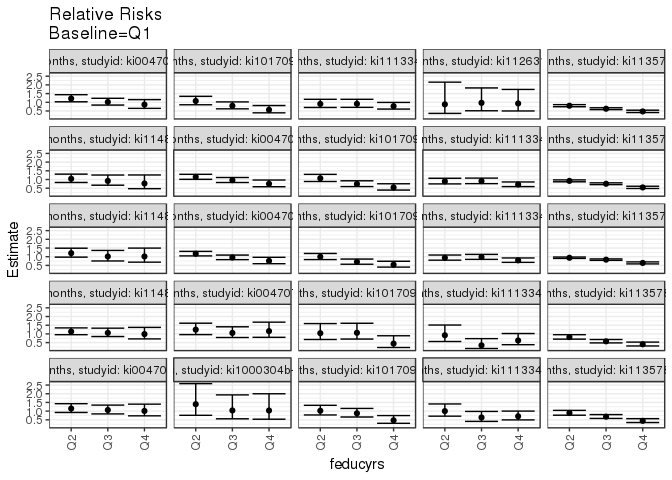

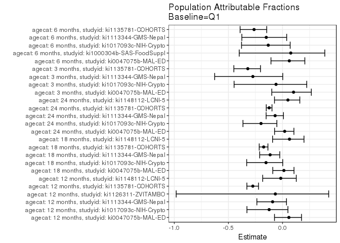

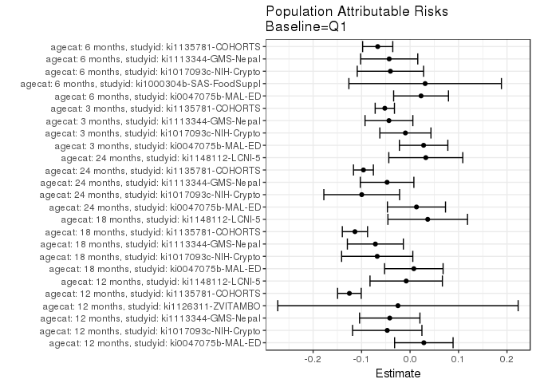

## Data Summary

| agecat | studyid | A | n | nA | nAY0 | nAY1 |
| --- | --- | --- | --- | --- | --- | --- |
| 3 months | ki0047075b-MAL-ED | Q1 | 966 | 287 | 216 | 71 |
| 3 months | ki0047075b-MAL-ED | Q2 | 966 | 318 | 220 | 98 |
| 3 months | ki0047075b-MAL-ED | Q3 | 966 | 260 | 192 | 68 |
| 3 months | ki0047075b-MAL-ED | Q4 | 966 | 101 | 72 | 29 |
| 3 months | ki1000304b-SAS-FoodSuppl | Q1 | 0 | 0 | 0 | 0 |
| 3 months | ki1000304b-SAS-FoodSuppl | Q2 | 0 | 0 | 0 | 0 |
| 3 months | ki1000304b-SAS-FoodSuppl | Q3 | 0 | 0 | 0 | 0 |
| 3 months | ki1000304b-SAS-FoodSuppl | Q4 | 0 | 0 | 0 | 0 |
| 3 months | ki1017093b-PROVIDE | Q1 | 175 | 78 | 54 | 24 |
| 3 months | ki1017093b-PROVIDE | Q2 | 175 | 51 | 37 | 14 |
| 3 months | ki1017093b-PROVIDE | Q3 | 175 | 36 | 31 | 5 |
| 3 months | ki1017093b-PROVIDE | Q4 | 175 | 10 | 9 | 1 |
| 3 months | ki1017093c-NIH-Crypto | Q1 | 758 | 195 | 162 | 33 |
| 3 months | ki1017093c-NIH-Crypto | Q2 | 758 | 210 | 173 | 37 |
| 3 months | ki1017093c-NIH-Crypto | Q3 | 758 | 233 | 191 | 42 |
| 3 months | ki1017093c-NIH-Crypto | Q4 | 758 | 120 | 111 | 9 |
| 3 months | ki1066203-TanzaniaChild2 | Q1 | 599 | 341 | 311 | 30 |
| 3 months | ki1066203-TanzaniaChild2 | Q2 | 599 | 181 | 164 | 17 |
| 3 months | ki1066203-TanzaniaChild2 | Q3 | 599 | 14 | 13 | 1 |
| 3 months | ki1066203-TanzaniaChild2 | Q4 | 599 | 63 | 52 | 11 |
| 3 months | ki1113344-GMS-Nepal | Q1 | 592 | 257 | 205 | 52 |
| 3 months | ki1113344-GMS-Nepal | Q2 | 592 | 91 | 74 | 17 |
| 3 months | ki1113344-GMS-Nepal | Q3 | 592 | 101 | 94 | 7 |
| 3 months | ki1113344-GMS-Nepal | Q4 | 592 | 143 | 125 | 18 |
| 3 months | ki1126311-ZVITAMBO | Q1 | 3424 | 15 | 11 | 4 |
| 3 months | ki1126311-ZVITAMBO | Q2 | 3424 | 23 | 21 | 2 |
| 3 months | ki1126311-ZVITAMBO | Q3 | 3424 | 448 | 352 | 96 |
| 3 months | ki1126311-ZVITAMBO | Q4 | 3424 | 2938 | 2325 | 613 |
| 3 months | ki1135781-COHORTS | Q1 | 4776 | 1642 | 1290 | 352 |
| 3 months | ki1135781-COHORTS | Q2 | 4776 | 1165 | 961 | 204 |

[output cut: 150 more lines]

## Results Table

### Parameter: TSM

| agecat | studyid | intervention_level | baseline_level | estimate | ci_lower | ci_upper |
| --- | --- | --- | --- | --- | --- | --- |
| 3 months | ki0047075b-MAL-ED | Q1 | NA | 0.2473868 | 0.1974401 | 0.2973334 |
| 3 months | ki0047075b-MAL-ED | Q2 | NA | 0.3081761 | 0.2574003 | 0.3589519 |
| 3 months | ki0047075b-MAL-ED | Q3 | NA | 0.2615385 | 0.2080921 | 0.3149848 |
| 3 months | ki0047075b-MAL-ED | Q4 | NA | 0.2871287 | 0.1988500 | 0.3754075 |
| 3 months | ki1017093c-NIH-Crypto | Q1 | NA | 0.1692308 | 0.1165688 | 0.2218928 |
| 3 months | ki1017093c-NIH-Crypto | Q2 | NA | 0.1761905 | 0.1246285 | 0.2277525 |
| 3 months | ki1017093c-NIH-Crypto | Q3 | NA | 0.1802575 | 0.1308671 | 0.2296479 |
| 3 months | ki1017093c-NIH-Crypto | Q4 | NA | 0.0750000 | 0.0278431 | 0.1221569 |
| 3 months | ki1113344-GMS-Nepal | Q1 | NA | 0.2023346 | 0.1531766 | 0.2514926 |
| 3 months | ki1113344-GMS-Nepal | Q2 | NA | 0.1868132 | 0.1066650 | 0.2669613 |
| 3 months | ki1113344-GMS-Nepal | Q3 | NA | 0.0693069 | 0.0197338 | 0.1188800 |
| 3 months | ki1113344-GMS-Nepal | Q4 | NA | 0.1258741 | 0.0714612 | 0.1802871 |
| 3 months | ki1135781-COHORTS | Q1 | NA | 0.2143727 | 0.1945209 | 0.2342245 |
| 3 months | ki1135781-COHORTS | Q2 | NA | 0.1751073 | 0.1532809 | 0.1969337 |
| 3 months | ki1135781-COHORTS | Q3 | NA | 0.1227679 | 0.1052212 | 0.1403145 |
| 3 months | ki1135781-COHORTS | Q4 | NA | 0.0864000 | 0.0643713 | 0.1084287 |
| 6 months | ki0047075b-MAL-ED | Q1 | NA | 0.3407407 | 0.2841760 | 0.3973055 |
| 6 months | ki0047075b-MAL-ED | Q2 | NA | 0.3907285 | 0.3356697 | 0.4457873 |
| 6 months | ki0047075b-MAL-ED | Q3 | NA | 0.3621399 | 0.3016776 | 0.4226023 |
| 6 months | ki0047075b-MAL-ED | Q4 | NA | 0.3440860 | 0.2474803 | 0.4406917 |
| 6 months | ki1000304b-SAS-FoodSuppl | Q1 | NA | 0.3783784 | 0.2213597 | 0.5353971 |
| 6 months | ki1000304b-SAS-FoodSuppl | Q2 | NA | 0.5294118 | 0.2910048 | 0.7678187 |
| 6 months | ki1000304b-SAS-FoodSuppl | Q3 | NA | 0.3928571 | 0.2110923 | 0.5746220 |
| 6 months | ki1000304b-SAS-FoodSuppl | Q4 | NA | 0.3913043 | 0.1908943 | 0.5917144 |
| 6 months | ki1017093c-NIH-Crypto | Q1 | NA | 0.3475936 | 0.2792941 | 0.4158931 |
| 6 months | ki1017093c-NIH-Crypto | Q2 | NA | 0.3543689 | 0.2890063 | 0.4197316 |
| 6 months | ki1017093c-NIH-Crypto | Q3 | NA | 0.3039648 | 0.2440881 | 0.3638414 |
| 6 months | ki1017093c-NIH-Crypto | Q4 | NA | 0.1637931 | 0.0963994 | 0.2311868 |
| 6 months | ki1113344-GMS-Nepal | Q1 | NA | 0.3292683 | 0.2704904 | 0.3880462 |
| 6 months | ki1113344-GMS-Nepal | Q2 | NA | 0.3296703 | 0.2329995 | 0.4263412 |

[output cut: 70 more lines]

### Parameter: E(Y)

| agecat | studyid | intervention_level | baseline_level | estimate | ci_lower | ci_upper |
| --- | --- | --- | --- | --- | --- | --- |
| 3 months | ki0047075b-MAL-ED | NA | NA | 0.2753623 | 0.2737502 | 0.2769745 |
| 3 months | ki1017093c-NIH-Crypto | NA | NA | 0.1596306 | 0.1569994 | 0.1622619 |
| 3 months | ki1113344-GMS-Nepal | NA | NA | 0.1587838 | 0.1546953 | 0.1628723 |
| 3 months | ki1135781-COHORTS | NA | NA | 0.1622697 | 0.1609497 | 0.1635897 |
| 6 months | ki0047075b-MAL-ED | NA | NA | 0.3634361 | 0.3620715 | 0.3648008 |
| 6 months | ki1000304b-SAS-FoodSuppl | NA | NA | 0.4095238 | 0.3993256 | 0.4197220 |
| 6 months | ki1017093c-NIH-Crypto | NA | NA | 0.3070652 | 0.3023346 | 0.3117958 |
| 6 months | ki1113344-GMS-Nepal | NA | NA | 0.2862191 | 0.2818616 | 0.2905766 |
| 6 months | ki1135781-COHORTS | NA | NA | 0.2535868 | 0.2512301 | 0.2559435 |
| 12 months | ki0047075b-MAL-ED | NA | NA | 0.4847112 | 0.4812233 | 0.4881991 |
| 12 months | ki1017093c-NIH-Crypto | NA | NA | 0.3799726 | 0.3744293 | 0.3855158 |
| 12 months | ki1113344-GMS-Nepal | NA | NA | 0.4561102 | 0.4525511 | 0.4596692 |
| 12 months | ki1126311-ZVITAMBO | NA | NA | 0.3750503 | 0.3748405 | 0.3752601 |
| 12 months | ki1135781-COHORTS | NA | NA | 0.4556291 | 0.4524652 | 0.4587931 |
| 12 months | ki1148112-LCNI-5 | NA | NA | 0.4833760 | 0.4798617 | 0.4868902 |
| 18 months | ki0047075b-MAL-ED | NA | NA | 0.6164875 | 0.6117352 | 0.6212397 |
| 18 months | ki1017093c-NIH-Crypto | NA | NA | 0.4433566 | 0.4360793 | 0.4506340 |
| 18 months | ki1113344-GMS-Nepal | NA | NA | 0.6247818 | 0.6182931 | 0.6312706 |
| 18 months | ki1135781-COHORTS | NA | NA | 0.6517550 | 0.6473412 | 0.6561687 |
| 18 months | ki1148112-LCNI-5 | NA | NA | 0.5679012 | 0.5624673 | 0.5733352 |
| 24 months | ki0047075b-MAL-ED | NA | NA | 0.6716604 | 0.6660208 | 0.6773000 |
| 24 months | ki1017093c-NIH-Crypto | NA | NA | 0.5015773 | 0.4929930 | 0.5101616 |
| 24 months | ki1113344-GMS-Nepal | NA | NA | 0.6913580 | 0.6861935 | 0.6965225 |
| 24 months | ki1135781-COHORTS | NA | NA | 0.7779720 | 0.7740933 | 0.7818508 |
| 24 months | ki1148112-LCNI-5 | NA | NA | 0.6542857 | 0.6503264 | 0.6582450 |

### Parameter: RR

| agecat | studyid | intervention_level | baseline_level | estimate | ci_lower | ci_upper |
| --- | --- | --- | --- | --- | --- | --- |
| 3 months | ki0047075b-MAL-ED | Q2 | Q1 | 1.2457259 | 0.9599490 | 1.6165786 |
| 3 months | ki0047075b-MAL-ED | Q3 | Q1 | 1.0572048 | 0.7932321 | 1.4090226 |
| 3 months | ki0047075b-MAL-ED | Q4 | Q1 | 1.1606471 | 0.8034500 | 1.6766465 |
| 3 months | ki1017093c-NIH-Crypto | Q2 | Q1 | 1.0411255 | 0.6791769 | 1.5959647 |
| 3 months | ki1017093c-NIH-Crypto | Q3 | Q1 | 1.0651580 | 0.7036328 | 1.6124341 |
| 3 months | ki1017093c-NIH-Crypto | Q4 | Q1 | 0.4431818 | 0.2197365 | 0.8938440 |
| 3 months | ki1113344-GMS-Nepal | Q2 | Q1 | 0.9232883 | 0.5639119 | 1.5116922 |
| 3 months | ki1113344-GMS-Nepal | Q3 | Q1 | 0.3425362 | 0.1609305 | 0.7290790 |
| 3 months | ki1113344-GMS-Nepal | Q4 | Q1 | 0.6221087 | 0.3788872 | 1.0214629 |
| 3 months | ki1135781-COHORTS | Q2 | Q1 | 0.8168357 | 0.6993542 | 0.9540525 |
| 3 months | ki1135781-COHORTS | Q3 | Q1 | 0.5726842 | 0.4830070 | 0.6790111 |
| 3 months | ki1135781-COHORTS | Q4 | Q1 | 0.4030365 | 0.3072830 | 0.5286280 |
| 6 months | ki0047075b-MAL-ED | Q2 | Q1 | 1.1467031 | 0.9223254 | 1.4256661 |
| 6 months | ki0047075b-MAL-ED | Q3 | Q1 | 1.0628019 | 0.8398490 | 1.3449417 |
| 6 months | ki0047075b-MAL-ED | Q4 | Q1 | 1.0098177 | 0.7287708 | 1.3992488 |
| 6 months | ki1000304b-SAS-FoodSuppl | Q2 | Q1 | 1.3991597 | 0.7584339 | 2.5811711 |
| 6 months | ki1000304b-SAS-FoodSuppl | Q3 | Q1 | 1.0382653 | 0.5576866 | 1.9329761 |
| 6 months | ki1000304b-SAS-FoodSuppl | Q4 | Q1 | 1.0341615 | 0.5349481 | 1.9992408 |
| 6 months | ki1017093c-NIH-Crypto | Q2 | Q1 | 1.0194922 | 0.7786485 | 1.3348312 |
| 6 months | ki1017093c-NIH-Crypto | Q3 | Q1 | 0.8744832 | 0.6620903 | 1.1550100 |
| 6 months | ki1017093c-NIH-Crypto | Q4 | Q1 | 0.4712202 | 0.2986759 | 0.7434427 |
| 6 months | ki1113344-GMS-Nepal | Q2 | Q1 | 1.0012210 | 0.7102938 | 1.4113083 |
| 6 months | ki1113344-GMS-Nepal | Q3 | Q1 | 0.6341066 | 0.4090777 | 0.9829213 |
| 6 months | ki1113344-GMS-Nepal | Q4 | Q1 | 0.7042405 | 0.4950434 | 1.0018406 |
| 6 months | ki1135781-COHORTS | Q2 | Q1 | 0.8933333 | 0.7648547 | 1.0433935 |
| 6 months | ki1135781-COHORTS | Q3 | Q1 | 0.6806500 | 0.5790221 | 0.8001152 |
| 6 months | ki1135781-COHORTS | Q4 | Q1 | 0.4409808 | 0.3439582 | 0.5653711 |
| 12 months | ki0047075b-MAL-ED | Q2 | Q1 | 1.2151077 | 1.0280713 | 1.4361716 |
| 12 months | ki0047075b-MAL-ED | Q3 | Q1 | 1.0165603 | 0.8401171 | 1.2300605 |
| 12 months | ki0047075b-MAL-ED | Q4 | Q1 | 0.8670330 | 0.6511464 | 1.1544965 |
| 12 months | ki1017093c-NIH-Crypto | Q2 | Q1 | 1.0737882 | 0.8585217 | 1.3430308 |
| 12 months | ki1017093c-NIH-Crypto | Q3 | Q1 | 0.7980928 | 0.6231005 | 1.0222301 |
| 12 months | ki1017093c-NIH-Crypto | Q4 | Q1 | 0.5652553 | 0.3929932 | 0.8130259 |
| 12 months | ki1113344-GMS-Nepal | Q2 | Q1 | 0.9068678 | 0.7016521 | 1.1721041 |
| 12 months | ki1113344-GMS-Nepal | Q3 | Q1 | 0.9108746 | 0.7081690 | 1.1716026 |
| 12 months | ki1113344-GMS-Nepal | Q4 | Q1 | 0.7777715 | 0.6107449 | 0.9904766 |
| 12 months | ki1126311-ZVITAMBO | Q2 | Q1 | 0.8823529 | 0.3609965 | 2.1566599 |
| 12 months | ki1126311-ZVITAMBO | Q3 | Q1 | 0.9674923 | 0.5127401 | 1.8255668 |
| 12 months | ki1126311-ZVITAMBO | Q4 | Q1 | 0.9330986 | 0.5007727 | 1.7386592 |
| 12 months | ki1135781-COHORTS | Q2 | Q1 | 0.8021870 | 0.7441910 | 0.8647028 |
| 12 months | ki1135781-COHORTS | Q3 | Q1 | 0.6300302 | 0.5790892 | 0.6854525 |
| 12 months | ki1135781-COHORTS | Q4 | Q1 | 0.4734962 | 0.4113170 | 0.5450751 |
| 12 months | ki1148112-LCNI-5 | Q2 | Q1 | 1.0416860 | 0.8293310 | 1.3084156 |
| 12 months | ki1148112-LCNI-5 | Q3 | Q1 | 0.9191651 | 0.6715954 | 1.2579961 |
| 12 months | ki1148112-LCNI-5 | Q4 | Q1 | 0.7720081 | 0.4728258 | 1.2604993 |
| 18 months | ki0047075b-MAL-ED | Q2 | Q1 | 1.1446622 | 1.0093931 | 1.2980587 |
| 18 months | ki0047075b-MAL-ED | Q3 | Q1 | 0.9607781 | 0.8284430 | 1.1142523 |
| 18 months | ki0047075b-MAL-ED | Q4 | Q1 | 0.7521515 | 0.5832879 | 0.9699015 |
| 18 months | ki1017093c-NIH-Crypto | Q2 | Q1 | 1.0707333 | 0.8850457 | 1.2953792 |
| 18 months | ki1017093c-NIH-Crypto | Q3 | Q1 | 0.7415128 | 0.5939691 | 0.9257068 |
| 18 months | ki1017093c-NIH-Crypto | Q4 | Q1 | 0.5444234 | 0.3924093 | 0.7553258 |
| 18 months | ki1113344-GMS-Nepal | Q2 | Q1 | 0.8935401 | 0.7456171 | 1.0708094 |
| 18 months | ki1113344-GMS-Nepal | Q3 | Q1 | 0.9069767 | 0.7618091 | 1.0798070 |
| 18 months | ki1113344-GMS-Nepal | Q4 | Q1 | 0.7129309 | 0.5921199 | 0.8583912 |
| 18 months | ki1135781-COHORTS | Q2 | Q1 | 0.9208705 | 0.8678279 | 0.9771552 |
| 18 months | ki1135781-COHORTS | Q3 | Q1 | 0.7549692 | 0.7046018 | 0.8089370 |
| 18 months | ki1135781-COHORTS | Q4 | Q1 | 0.5432662 | 0.4824450 | 0.6117551 |
| 18 months | ki1148112-LCNI-5 | Q2 | Q1 | 1.2056719 | 0.9758427 | 1.4896303 |
| 18 months | ki1148112-LCNI-5 | Q3 | Q1 | 1.0131579 | 0.7540122 | 1.3613691 |
| 18 months | ki1148112-LCNI-5 | Q4 | Q1 | 1.0131579 | 0.6871219 | 1.4938964 |
| 24 months | ki0047075b-MAL-ED | Q2 | Q1 | 1.1691509 | 1.0452404 | 1.3077508 |
| 24 months | ki0047075b-MAL-ED | Q3 | Q1 | 0.9536337 | 0.8314094 | 1.0938261 |
| 24 months | ki0047075b-MAL-ED | Q4 | Q1 | 0.7593750 | 0.5974427 | 0.9651978 |
| 24 months | ki1017093c-NIH-Crypto | Q2 | Q1 | 0.9960474 | 0.8365539 | 1.1859493 |
| 24 months | ki1017093c-NIH-Crypto | Q3 | Q1 | 0.7002288 | 0.5670316 | 0.8647144 |
| 24 months | ki1017093c-NIH-Crypto | Q4 | Q1 | 0.5436873 | 0.4008857 | 0.7373570 |
| 24 months | ki1113344-GMS-Nepal | Q2 | Q1 | 0.9371016 | 0.8017131 | 1.0953536 |
| 24 months | ki1113344-GMS-Nepal | Q3 | Q1 | 0.9791936 | 0.8464941 | 1.1326955 |
| 24 months | ki1113344-GMS-Nepal | Q4 | Q1 | 0.7904182 | 0.6736182 | 0.9274704 |
| 24 months | ki1135781-COHORTS | Q2 | Q1 | 0.9388573 | 0.8995528 | 0.9798791 |
| 24 months | ki1135781-COHORTS | Q3 | Q1 | 0.8307477 | 0.7908665 | 0.8726400 |
| 24 months | ki1135781-COHORTS | Q4 | Q1 | 0.6411803 | 0.5864143 | 0.7010609 |
| 24 months | ki1148112-LCNI-5 | Q2 | Q1 | 1.1343888 | 0.9556736 | 1.3465245 |
| 24 months | ki1148112-LCNI-5 | Q3 | Q1 | 1.0625920 | 0.8490211 | 1.3298867 |
| 24 months | ki1148112-LCNI-5 | Q4 | Q1 | 0.9896907 | 0.7128886 | 1.3739703 |

### Parameter: PAR

| agecat | studyid | intervention_level | baseline_level | estimate | ci_lower | ci_upper |
| --- | --- | --- | --- | --- | --- | --- |
| 3 months | ki0047075b-MAL-ED | Q1 | NA | 0.0279756 | -0.0219971 | 0.0779482 |
| 3 months | ki1017093c-NIH-Crypto | Q1 | NA | -0.0096002 | -0.0623279 | 0.0431275 |
| 3 months | ki1113344-GMS-Nepal | Q1 | NA | -0.0435508 | -0.0928786 | 0.0057769 |
| 3 months | ki1135781-COHORTS | Q1 | NA | -0.0521030 | -0.0719987 | -0.0322074 |
| 6 months | ki0047075b-MAL-ED | Q1 | NA | 0.0226954 | -0.0338858 | 0.0792766 |
| 6 months | ki1000304b-SAS-FoodSuppl | Q1 | NA | 0.0311454 | -0.1262041 | 0.1884950 |
| 6 months | ki1017093c-NIH-Crypto | Q1 | NA | -0.0405284 | -0.1089915 | 0.0279348 |
| 6 months | ki1113344-GMS-Nepal | Q1 | NA | -0.0430492 | -0.1019884 | 0.0158900 |
| 6 months | ki1135781-COHORTS | Q1 | NA | -0.0667347 | -0.0978170 | -0.0356523 |
| 12 months | ki0047075b-MAL-ED | Q1 | NA | 0.0284374 | -0.0318943 | 0.0887692 |
| 12 months | ki1017093c-NIH-Crypto | Q1 | NA | -0.0470545 | -0.1185967 | 0.0244878 |
| 12 months | ki1113344-GMS-Nepal | Q1 | NA | -0.0418818 | -0.1041405 | 0.0203768 |
| 12 months | ki1126311-ZVITAMBO | Q1 | NA | -0.0249497 | -0.2729177 | 0.2230183 |
| 12 months | ki1135781-COHORTS | Q1 | NA | -0.1251569 | -0.1495209 | -0.1007929 |
| 12 months | ki1148112-LCNI-5 | Q1 | NA | -0.0079535 | -0.0826272 | 0.0667201 |
| 18 months | ki0047075b-MAL-ED | Q1 | NA | 0.0077918 | -0.0525690 | 0.0681526 |
| 18 months | ki1017093c-NIH-Crypto | Q1 | NA | -0.0677545 | -0.1411926 | 0.0056836 |
| 18 months | ki1113344-GMS-Nepal | Q1 | NA | -0.0715744 | -0.1293354 | -0.0138134 |
| 18 months | ki1135781-COHORTS | Q1 | NA | -0.1137360 | -0.1397570 | -0.0877149 |
| 18 months | ki1148112-LCNI-5 | Q1 | NA | 0.0364327 | -0.0456616 | 0.1185270 |
| 24 months | ki0047075b-MAL-ED | Q1 | NA | 0.0132242 | -0.0467053 | 0.0731537 |
| 24 months | ki1017093c-NIH-Crypto | Q1 | NA | -0.0997299 | -0.1778478 | -0.0216120 |
| 24 months | ki1113344-GMS-Nepal | Q1 | NA | -0.0474175 | -0.1027161 | 0.0078811 |
| 24 months | ki1135781-COHORTS | Q1 | NA | -0.0961874 | -0.1167087 | -0.0756662 |
| 24 months | ki1148112-LCNI-5 | Q1 | NA | 0.0324908 | -0.0438189 | 0.1088005 |

### Parameter: PAF

| agecat | studyid | intervention_level | baseline_level | estimate | ci_lower | ci_upper |
| --- | --- | --- | --- | --- | --- | --- |
| 3 months | ki0047075b-MAL-ED | Q1 | NA | 0.1015955 | -0.0994906 | 0.2659049 |
| 3 months | ki1017093c-NIH-Crypto | Q1 | NA | -0.0601399 | -0.4477659 | 0.2237029 |
| 3 months | ki1113344-GMS-Nepal | Q1 | NA | -0.2742777 | -0.6269288 | 0.0019332 |
| 3 months | ki1135781-COHORTS | Q1 | NA | -0.3210891 | -0.4497879 | -0.2038151 |
| 6 months | ki0047075b-MAL-ED | Q1 | NA | 0.0624467 | -0.1069029 | 0.2058868 |
| 6 months | ki1000304b-SAS-FoodSuppl | Q1 | NA | 0.0760528 | -0.4002128 | 0.3903224 |
| 6 months | ki1017093c-NIH-Crypto | Q1 | NA | -0.1319862 | -0.3786010 | 0.0705123 |
| 6 months | ki1113344-GMS-Nepal | Q1 | NA | -0.1504065 | -0.3761283 | 0.0382909 |
| 6 months | ki1135781-COHORTS | Q1 | NA | -0.2631630 | -0.3921088 | -0.1461610 |
| 12 months | ki0047075b-MAL-ED | Q1 | NA | 0.0586688 | -0.0743778 | 0.1752395 |
| 12 months | ki1017093c-NIH-Crypto | Q1 | NA | -0.1238365 | -0.3289858 | 0.0496449 |
| 12 months | ki1113344-GMS-Nepal | Q1 | NA | -0.0918239 | -0.2372711 | 0.0365253 |
| 12 months | ki1126311-ZVITAMBO | Q1 | NA | -0.0665236 | -0.9824321 | 0.4262237 |
| 12 months | ki1135781-COHORTS | Q1 | NA | -0.2746903 | -0.3295941 | -0.2220536 |
| 12 months | ki1148112-LCNI-5 | Q1 | NA | -0.0164541 | -0.1833017 | 0.1268677 |
| 18 months | ki0047075b-MAL-ED | Q1 | NA | 0.0126390 | -0.0902825 | 0.1058449 |
| 18 months | ki1017093c-NIH-Crypto | Q1 | NA | -0.1528216 | -0.3312624 | 0.0017012 |
| 18 months | ki1113344-GMS-Nepal | Q1 | NA | -0.1145591 | -0.2111048 | -0.0257097 |
| 18 months | ki1135781-COHORTS | Q1 | NA | -0.1745072 | -0.2153430 | -0.1350436 |
| 18 months | ki1148112-LCNI-5 | Q1 | NA | 0.0641532 | -0.0921206 | 0.1980655 |
| 24 months | ki0047075b-MAL-ED | Q1 | NA | 0.0196888 | -0.0737068 | 0.1049605 |
| 24 months | ki1017093c-NIH-Crypto | Q1 | NA | -0.1988326 | -0.3656141 | -0.0524200 |
| 24 months | ki1113344-GMS-Nepal | Q1 | NA | -0.0685860 | -0.1516944 | 0.0085251 |
| 24 months | ki1135781-COHORTS | Q1 | NA | -0.1236387 | -0.1504550 | -0.0974474 |
| 24 months | ki1148112-LCNI-5 | Q1 | NA | 0.0496585 | -0.0744136 | 0.1594029 |